# MUSA508_FINAL_SFPARK

## ROC Curve

The area under our model’s ROC curve is 0.88. An AUC value that falls in the 0.60-0.70 range is considered poor. This tells us that our model is fairly accurate.

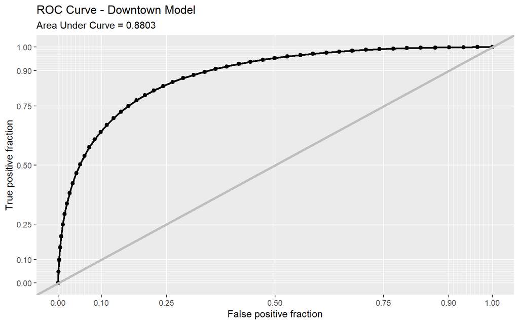

```r
#library(rROC)

library(plotROC)

ggplot() +
  geom_roc(
    data = focus.ROC,
    aes(d = labels, m = predictions),
    n.cuts = 50, labels = FALSE, colour = "#000000") +
  # geom_roc(
  #   data = test.predict,
  #   aes(d = as.numeric(test.predict$outcome), m = predict.2),
  #   n.cuts = 50, labels = FALSE, colour = "#FE9900") +
  style_roc(theme = theme_grey) +
  geom_abline(slope = 1, intercept = 0, size = 1.5, color = 'grey') +
  labs(
    title = "ROC Curve - Downtown Model",
    subtitle = glue("Area Under Curve = {AUC}")
    )
```

## CV

```r
library(caret)

park.train.dwtn.prep =
  park.train.dwtn %>%
      dplyr::select(dwtn_vars) %>%
      mutate(occ50 = ifelse(occ50==TRUE, "ABOVE50", "BELOW50"))  %>%
  na.omit()
park.train.dwtn.prep$occ50 = park.train.dwtn.prep$occ50 %>% as.factor()

# control CV parameters
ctrl = trainControl(
  method = "cv",
  number = 100,
  classProbs=TRUE,
  summaryFunction=twoClassSummary #(data=park.train.dwtn.prep, lev=c(1,0))
  )

form = colnames(park.train.dwtn.prep)
form = form[form!='occ50'&form!='id.dist']
#form = paste(form, collapse=' + ') %>% paste('occ50', ., sep=' ~ ') %>% as.formula()
library(pROC)
## Type 'citation("pROC")' for a citation.
##
## Attaching package: 'pROC'
## The following object is masked from 'package:plotROC':
##
##     ggroc
## The following objects are masked from 'package:stats':
##
##     cov, smooth, var
# cv LM
park.cv.dwtn = caret::train(
  x = park.train.dwtn.prep %>% dplyr::select(form),
  y = park.train.dwtn.prep$occ50,
  method="glm",
  family="binomial",
  metric="ROC",
  trControl = ctrl
  )
## Note: Using an external vector in selections is ambiguous.
## i Use `all_of(form)` instead of `form` to silence this message.
## i See <https://tidyselect.r-lib.org/reference/faq-external-vector.html>.
## This message is displayed once per session.
```

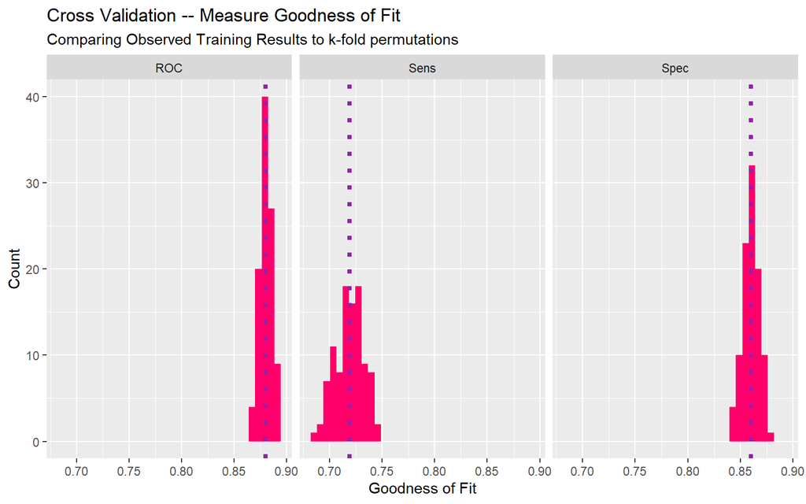

```r
dplyr::select(park.cv.dwtn$resample, -Resample) %>%
  gather(metric, value) %>%
  left_join(gather(park.cv.dwtn$results[2:4], metric, mean)) %>%
  ggplot(aes(value)) +
    geom_histogram(bins=35, fill = "#FF006A") +
    facet_wrap(~metric) +
    geom_vline(aes(xintercept = mean), colour = "#981FAC", linetype = 3, size = 1.5) +
    #scale_x_continuous(limits = c(0, 1)) +
    labs(x="Goodness of Fit", y="Count", title="Cross Validation -- Measure Goodness of Fit",
         subtitle = "Comparing Observed Training Results to k-fold permutations")
## Joining, by = "metric"
```

## Map

This map displays the misclassification rate of the Downtown model. It helps the team evaluate which geographic areas are being misclassified. It appears that blocks with heavier occupations also have higher missclassifications. This aligns with the Test model summary and ROC results that we are predicting better for lower occupancies and not higher occupancies.

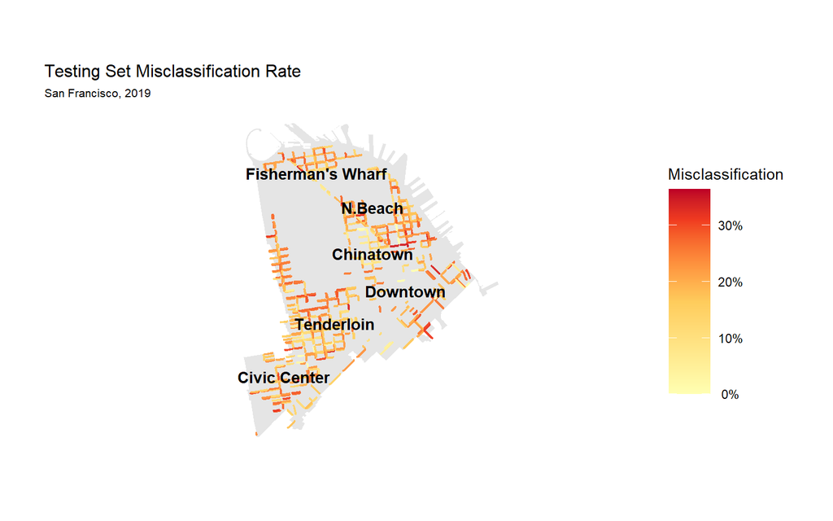

```r
#SF.quad.labels = sf_to_labels(SF.quad, 'quad') %>% dplyr::filter(label=='NE')
SF.dist.labels = sf_to_labels(
  SF.dist %>% arrange(quad) %>%
    dplyr::filter(quad=='NE') %>%
    dplyr::filter(!PM_DISTRICT_NAME  %in% c(
      'Polk', 'Telegraph Hill'
    )), 'PM_DISTRICT_NAME') %>%
  mutate(label =
    ifelse(
      label == 'N.Beach-Chinatown',
      'N.Beach\n\nChinatown',
    ifelse(
      label == "Fisherman's Wharf",
      "\nFisherman's Wharf",
           label)
      ) #%>% gsub(' ','\n', ., fixed = TRUE)
    )

park.map =
  park.test.dwtn %>%
    dplyr::group_by(id.block, occ50, occ50.predict) %>%
    dplyr::summarize(
      count = n()
    ) %>%
  mutate(
    Outcome =
      case_when(
        occ50 == TRUE & occ50.predict == TRUE ~ 'True Positive',
        occ50 == TRUE & occ50.predict == FALSE ~ 'False Negative',
        occ50 == FALSE & occ50.predict == TRUE ~ 'False Positive',
        occ50 == FALSE & occ50.predict == FALSE ~ 'True Negative'
      )
  ) %>% ungroup() %>%
  dplyr::select(id.block,Outcome,count) %>%
  dcast(., id.block~Outcome, fill=0) %>%
  mutate(
    Misclassification = (`False Negative` + `False Positive`) /
      (`False Negative` + `False Positive` + `True Negative` + `True Positive`)
  ) %>%
  merge(
    .,
    park.blocks,
    on='id.block'
  ) %>%
  st_sf() %>%
  st_buffer(50)
## `summarise()` has grouped output by 'id.block', 'occ50'. You can override using the `.groups` argument.
## Using 'count' as value column. Use 'value.var' to override

#park.map$bin = factor(park.map$bin, levels = c("All","9a to 12p", "12p to 3p", "3p to 6p"))
# park.map$day.week = factor(
#   park.map$day.week,
#   levels =
#     c("Monday", "Tuesday", "Wednesday", "Thursday", "Friday", "Saturday", "Sunday"))
sep = 10000
ggplot()+
  geom_sf(
    data = SF.quad %>%
      dplyr::filter(quad=='NE'), color = 'transparent', fill='grey90'
  ) +
  geom_sf(data = park.map,
          aes(fill = Misclassification), #, size=meters.count),
          color = "transparent", alpha = 0.95
          ) +
  geom_text_sf(
    SF.dist.labels, check_overlap = TRUE,

    #hjust = "top"#, vjust = "outward"
    ) +
  xlim(min(SF.dist.labels$lon)-sep, max(SF.dist.labels$lon)+sep) +
  scale_fill_gradientn(
    colors = RColorBrewer::brewer.pal(5, "YlOrRd"),
    values = c(0,.45,.65,.85,1),
    labels = function(tstr) percent_formatter(tstr)
    #direction = -1, discrete = FALSE, option = "D"
    )+
  guides(fill = guide_colourbar(barwidth = 2)) +
  #facet_wrap(~bin, ncol = 2)+
  labs(
    title='Testing Set Misclassification Rate',
    subtitle = 'San Francisco, 2019'
    )+
  mapTheme
```

```r
geom_text()
```

# Conclusion

## Use Case Results

*Like any good Silicon Valley app,* our app is promising in theory but a devil’s errand in reality. The app’s ability to predict open parking spots hinges on the a single city’s uncleaned dataset. Regardless, the second, downtown model appeared to provide a rough estimation of which blocks are more occupied in a given area or time. Our final application would simply take in the list of blocks and their predicted odds.

## Improvements

Before the app goes to market, I believe there are large gaps for improvement, specifically for the:

1. **Dependent Variable** It would be better to determine the *probability that a single parking spot is open*. A block could have a low average occupation rate but only have 2 parking spots – that could get filled up. This would require a heavier amount of cleaning and a different model.

At the same time, the meter data only provides parking space times that have metered transactions. The city still has a large amount of illegal parking and free neighborhood parking.

2. **Model Type** The app’s focus on finding a single parking spot suggests it would be better to look at the probability of 1 or 2 spots being open. A Temple-based spatial statistics professor suggested to the team that a *ordinal logistic regression model* could find the probability of 0, 1, or 2+ spots being open. The model’s added complexity is, however, outside the confines of this app development team’s current timeline and pay grade.
3. **Improved Data Cleaning** The cleaned parking meter transactions provide an average occupancy rate (~42%) that feels tremendously lower than anecdotal evidence or SFMTA’s pricing rates (which suggest 60-80% occupancy). Overall the parking dataset is large and murky. Many transaction appear to be administrative (e.g. parking transaction from midnight to 10am) but there isn’t a column describing this transaction. If the app garners public support, SFMTA could provide the team with a cleaner dataset.
4. **Improved Predictor Variables** The model had a lower AIC score and a promising ROC Curve, but the relatively low True Positive Rate suggests that the model is more ambiguous at predicting higher occupancy parking meters. Some helpful predictor variables that could predict high demand are: event times & locations, commercial center locations, and San Francisco landmarks. Another set of predictors are the location of free on-street parking spaces and paid off-street parking spots.
5. **Enlarging Study Area & City** The final model only looked at Downtown San Francisco and at metered spots. IF we had the data for non-metered parking spots, the app user would benefit in not having to spend money.